# Lab 11 Part 2: Partial Pooling — and the Question That Comes Before It

ECON 8310: Business Forecasting — University of Nebraska at Omaha

# What we are doing

A hierarchical model lets thirty series share information: each gets its own effect, drawn from a common distribution the data also estimates. Data-poor series borrow from data-rich ones, and nobody has to choose the weights.

That is genuinely powerful, and today you will watch it work. You will also watch it produce a confidently wrong answer — on the same data, with clean diagnostics, textbook shrinkage, and no warning of any kind.

The difference between the two runs is not the code. It is a decision made before any code was written: **which series belong in the same hierarchy.**

**Suggested time:** ~45 minutes · **You will need:** `pandas`, `numpy`, `matplotlib`, `pymc`, `arviz`, and `data/processed/m5_weekly.csv`. Five model fits, most under 30 seconds.

# Setup

```python
import pandas as pd
import numpy as np
import matplotlib.pyplot as plt
import pymc as pm
import arviz as az
import warnings

warnings.filterwarnings("ignore")
RANDOM_STATE = 42

weekly = pd.read_csv("../data/processed/m5_weekly.csv", parse_dates=["week_start"])
weekly["series"] = weekly.store_id + "_" + weekly.cat_id
weekly["hi_snap"] = (weekly.snap_days >= 5).astype(int)

df = weekly.dropna(subset=["units"]).copy()
df["ly"] = np.log(df.units.clip(lower=1))

print(f"{df.series.nunique()} series | {len(df):,} rows | "
      f"{df.hi_snap.mean():.1%} of weeks are high-SNAP")
```

```
30 series | 8,310 rows | 22.1% of weeks are high-SNAP
```

Our question: **does a high-SNAP week lift units, and by how much in each store?**

We will need one helper repeatedly — the SNAP effect actually observed in a set of weeks, with no model involved. It is just the difference in mean log units between high-SNAP weeks and the rest.

```python
def empirical_effect(frame, series_name):
    """Observed high-SNAP effect on log units for one series."""
    z = frame[frame.series == series_name]
    if z.hi_snap.nunique() < 2:
        return np.nan
    return z.ly[z.hi_snap == 1].mean() - z.ly[z.hi_snap == 0].mean()
```

# Step 1 — Build the imbalance

Real panels are lopsided: some series have years of history, others are new stores or newly re-categorized products with a handful of usable weeks. We create that imbalance deliberately so we can check the answer later.

Thin every third series down to 8 weeks. The weeks we remove are not thrown away — they become a held-out set that the model never sees, and that we will use in Step 3 to grade it.

```python
codes, uniq = pd.factorize(df.series)
df["idx"] = codes
J = len(uniq)

rng = np.random.RandomState(RANDOM_STATE)
keep = []
for j in range(J):
    rows = df.index[df.idx == j].tolist()
    n = 8 if j % 3 == 0 else len(rows)
    keep += list(rng.choice(rows, size=min(n, len(rows)), replace=False))

train = df.loc[sorted(keep)].copy()
heldout = df.drop(index=keep).copy()
thin = np.array([j % 3 == 0 for j in range(J)])

print(f"train {len(train):,} rows | held-out {len(heldout):,} rows")
print(f"{thin.sum()} thin series (8 weeks each), {(~thin).sum()} full series")
```

```
train 5,620 rows | held-out 2,690 rows
10 thin series (8 weeks each), 20 full series
```

Here is the model. It is the one from lecture, written non-centered, and it takes a flag so we can reuse it for the unpooled fit.

```python
def fit(data, kind, n_series, centered=False, target_accept=0.9):
    """kind: 'unpooled' or 'hier'. Returns the InferenceData."""
    i = data.idx.values
    x = data.hi_snap.values.astype(float)
    y = data.ly.values
    with pm.Model():
        a = pm.Normal("a", y.mean(), 1, shape=n_series)
        s = pm.Exponential("s", 1.0)
        if kind == "unpooled":
            b = pm.Normal("b", 0, 0.5, shape=n_series)
        else:
            mu_b = pm.Normal("mu_b", 0, 0.5)
            sd_b = pm.HalfNormal("sd_b", 0.25)
            if centered:
                b = pm.Normal("b", mu_b, sd_b, shape=n_series)
            else:
                z = pm.Normal("z", 0, 1, shape=n_series)
                b = pm.Deterministic("b", mu_b + z * sd_b)
        pm.Normal("obs", mu=a[i] + b[i] * x, sigma=s, observed=y)
        return pm.sample(1000, tune=1500, chains=4, progressbar=False,
                         random_seed=RANDOM_STATE, target_accept=target_accept)

def b_means(idata, n_series):
    return az.summary(idata, var_names=["b"], ci_kind="hdi",
                      ci_prob=0.94)["mean"].values
```

# Step 2 — Fit it, and admire the shrinkage

Fit both models on all thirty series and measure how far each estimate moved.

```python
idata_u30 = fit(train, "unpooled", J)
idata_h30 = fit(train, "hier", J)

bu30, bh30 = b_means(idata_u30, J), b_means(idata_h30, J)

def diag(idata, label):
    su = az.summary(idata, var_names=["b"], ci_kind="hdi", ci_prob=0.94)
    print(f"  {label:<14s} r_hat {su.r_hat.max():.3f}  "
          f"ess {su.ess_bulk.min():5.0f}  "
          f"divergences {int(idata.sample_stats.diverging.sum()):4d}")

print("Diagnostics")
diag(idata_u30, "unpooled")
diag(idata_h30, "hierarchical")
```

```
Diagnostics
  unpooled       r_hat 1.003  ess  6100  divergences    0
  hierarchical   r_hat 1.003  ess  5077  divergences    0
```

```python
move_thin = np.abs(bh30[thin] - bu30[thin]).mean()
move_full = np.abs(bh30[~thin] - bu30[~thin]).mean()

print("\n              unpooled spread   after pooling   mean move")
print(f"  thin (8w)       {bu30[thin].std():.3f}           "
      f"{bh30[thin].std():.3f}          {move_thin:.3f}")
print(f"  full (277w)     {bu30[~thin].std():.3f}           "
      f"{bh30[~thin].std():.3f}          {move_full:.3f}")
print(f"\n  ratio: thin series moved {move_thin / move_full:.1f}x further")

g = az.summary(idata_h30, var_names=["mu_b", "sd_b"], ci_kind="hdi", ci_prob=0.94)
print(f"  mu_b {g.loc['mu_b','mean']:.3f}   sd_b {g.loc['sd_b','mean']:.3f}")
```

```
              unpooled spread   after pooling   mean move
  thin (8w)       0.106           0.000          0.111
  full (277w)     0.012           0.001          0.009

  ratio: thin series moved 11.9x further
  mu_b 0.011   sd_b 0.007
```

Everything a hierarchical model is supposed to do, it did. Diagnostics are clean. The data-poor series moved an order of magnitude further toward the group mean than the data-rich ones, and nobody told the model which was which.

The shrinkage plot makes it visual.

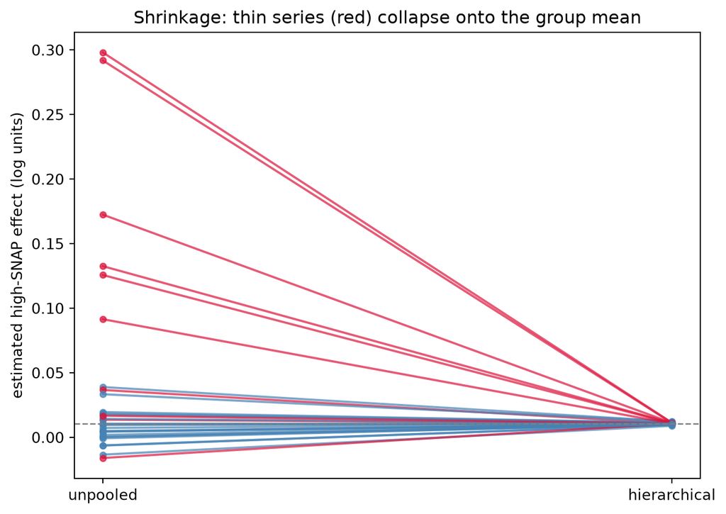

Each line is one series, before and after pooling.

```python
fig, ax = plt.subplots(figsize=(7, 5))
for j in range(J):
    c = "crimson" if thin[j] else "steelblue"
    ax.plot([0, 1], [bu30[j], bh30[j]], "-o", color=c, alpha=0.7, ms=4)
ax.axhline(g.loc["mu_b", "mean"], ls="--", c="gray", lw=1)
ax.set_xticks([0, 1]); ax.set_xticklabels(["unpooled", "hierarchical"])
ax.set_ylabel("estimated high-SNAP effect (log units)")
ax.set_title("Shrinkage: thin series (red) collapse onto the group mean")
plt.tight_layout(); plt.show()
```

**Before you go on**

Write down, in one sentence, what you would now tell the business. Keep it — Step 3 will ask whether it was right.

# Step 3 — Grade it against the weeks it never saw

We thinned those ten series ourselves. The weeks we removed are sitting in `heldout`, and each thinned series has hundreds of them. So we can compute the effect that *actually* occurred and compare.

```python
thin_names = [uniq[j] for j in range(J) if thin[j]]
truth = np.array([empirical_effect(heldout, s) for s in thin_names])
est_u = np.array([bu30[j] for j in range(J) if thin[j]])
est_h = np.array([bh30[j] for j in range(J) if thin[j]])

out = pd.DataFrame({"series": thin_names, "unpooled": est_u.round(3),
                    "hierarchical": est_h.round(3), "held_out_truth": truth.round(3)})
print(out.to_string(index=False))

rmse = lambda e: np.sqrt(np.nanmean((e - truth) ** 2))
print(f"\n  RMSE vs truth:  unpooled {rmse(est_u):.3f}   "
      f"hierarchical {rmse(est_h):.3f}")
print(f"  mean held-out effect across these series: {np.nanmean(truth):.3f}")
```

```
    series  unpooled  hierarchical  held_out_truth
CA_1_FOODS     0.298         0.011           0.087
CA_2_FOODS     0.014         0.011           0.011
CA_3_FOODS     0.037         0.011           0.105
CA_4_FOODS     0.126         0.011           0.039
TX_1_FOODS     0.092         0.011           0.082
TX_2_FOODS     0.172         0.011           0.067
TX_3_FOODS     0.133         0.011           0.074
WI_1_FOODS    -0.016         0.011           0.033
WI_2_FOODS     0.292         0.011           0.209
WI_3_FOODS     0.017         0.011           0.177

  RMSE vs truth:  unpooled 0.103   hierarchical 0.098
  mean held-out effect across these series: 0.089
```

Read that table before reading on.

The hierarchical model reported an effect near `mu_b` for every one of these series. The held-out weeks say the true effects average close to 0.09 — several times larger. The model did not merely lose precision on these series; it moved them all to the wrong place, and reported tight intervals around it.

And notice what the RMSE column says: pooling barely improved on the unpooled fit at all. All that shrinkage bought us essentially nothing.

**The diagnostics could never have caught this**

$\hat{R}$, ESS and divergences ask whether the sampler explored the posterior of *the model you wrote*. They cannot ask whether that model was the right one. Every diagnostic here passed.

# Step 4 — Find out what went wrong

Two things are wrong, and one of them is invisible until you look.

First, look at which series we thinned.

```python
print("thinned series:", thin_names)
```

```
thinned series: ['CA_1_FOODS', 'CA_2_FOODS', 'CA_3_FOODS', 'CA_4_FOODS', 'TX_1_FOODS', 'TX_2_FOODS', 'TX_3_FOODS', 'WI_1_FOODS', 'WI_2_FOODS', 'WI_3_FOODS']
```

```python
print("\nEmpirical high-SNAP effect by category (all data, no model):")
for cat, grp in df.groupby("cat_id"):
    effs = [empirical_effect(grp, s) for s in grp.series.unique()]
    print(f"  {cat:<10s} n={len(effs):2d}  mean {np.mean(effs):+.3f}  "
          f"sd {np.std(effs):.3f}")
```

```
Empirical high-SNAP effect by category (all data, no model):
  FOODS      n=10  mean +0.089  sd 0.058
  HOBBIES    n=10  mean +0.006  sd 0.010
  HOUSEHOLD  n=10  mean +0.011  sd 0.014
```

Two findings, and they compound.

**The groups were not exchangeable.** SNAP is a *food* assistance program. FOODS responds; HOBBIES and HOUSEHOLD barely move. Putting all thirty in one hierarchy told the model these are thirty interchangeable draws from one distribution — so it estimated a group mean near zero, dominated by the twenty series with no effect, and pulled the FOODS series down to it.

**And `j % 3 == 0` selected exactly the FOODS series.** The series are ordered store-major with three categories each, so every third one is a FOODS series. We starved precisely the ten series that had something to say, then pooled them toward twenty that did not.

**Exchangeability is a modeling assumption, and it is yours to defend**

Groups are exchangeable when, before seeing the data, you have no reason to expect one to differ from another in a particular direction. Ten FOODS series in ten stores: plausible. FOODS against HOBBIES: you knew the answer before you looked.

Nothing in PyMC checks this. No diagnostic reports it. It is subject-matter knowledge, applied before the model is written.

```python
# ---- your turn: uncomment and answer in the strings ----
# whose_fault = "..."   # <- would a bigger sample have fixed this? why or why not?
# print(whose_fault)
```

# Step 5 — Do it on the exchangeable set

Restrict to the ten FOODS series — the set we can actually defend pooling — and rebuild the same imbalance: thin every other one to 8 weeks.

```python
foods = df[df.cat_id == "FOODS"].copy()
codes_f, uniq_f = pd.factorize(foods.series)
foods["idx"] = codes_f
Jf = len(uniq_f)

rng = np.random.RandomState(RANDOM_STATE)
keep_f = []
for j in range(Jf):
    rows = foods.index[foods.idx == j].tolist()
    n = 8 if j % 2 == 0 else len(rows)
    keep_f += list(rng.choice(rows, size=min(n, len(rows)), replace=False))

train_f = foods.loc[sorted(keep_f)].copy()
heldout_f = foods.drop(index=keep_f).copy()
thin_f = np.array([j % 2 == 0 for j in range(Jf)])

print(f"{Jf} FOODS series | {thin_f.sum()} thinned to 8 weeks")
print(f"train {len(train_f):,} rows | held-out {len(heldout_f):,} rows")
```

```
10 FOODS series | 5 thinned to 8 weeks
train 1,425 rows | held-out 1,345 rows
```

```python
idata_uf = fit(train_f, "unpooled", Jf)
idata_hf = fit(train_f, "hier", Jf)
buf, bhf = b_means(idata_uf, Jf), b_means(idata_hf, Jf)

gf = az.summary(idata_hf, var_names=["mu_b", "sd_b"], ci_kind="hdi", ci_prob=0.94)
print(gf.round(3).to_string())
```

```
       mean     sd hdi94_lb hdi94_ub ess_bulk ess_tail r_hat mcse_mean  mcse_sd
mu_b  0.078  0.035    0.017     0.15     1544     1588  1.00   0.00092  0.00082
sd_b  0.065  0.038   0.0097     0.16     1027     1153  1.00    0.0011   0.0011
```

```python
mt = np.abs(bhf[thin_f] - buf[thin_f]).mean()
mf = np.abs(bhf[~thin_f] - buf[~thin_f]).mean()
print("              unpooled spread   after pooling   mean move")
print(f"  thin (8w)       {buf[thin_f].std():.3f}           "
      f"{bhf[thin_f].std():.3f}          {mt:.3f}")
print(f"  full (277w)     {buf[~thin_f].std():.3f}           "
      f"{bhf[~thin_f].std():.3f}          {mf:.3f}")
print(f"\n  ratio: thin moved {mt / mf:.1f}x further")
```

```
              unpooled spread   after pooling   mean move
  thin (8w)       0.108           0.010          0.120
  full (277w)     0.055           0.037          0.015

  ratio: thin moved 8.1x further
```

Compare that middle column to Step 2’s. There, *everything* collapsed onto the group mean. Here the thin series collapse but the full series **keep most of their spread** — the model discarded variation that 8 weeks could not support and kept variation that 277 weeks could. That is what partial pooling is supposed to look like.

Now grade it the same way.

```python
tn = [uniq_f[j] for j in range(Jf) if thin_f[j]]
truth_f = np.array([empirical_effect(heldout_f, s) for s in tn])
eu = np.array([buf[j] for j in range(Jf) if thin_f[j]])
eh = np.array([bhf[j] for j in range(Jf) if thin_f[j]])

print(pd.DataFrame({"series": tn, "unpooled": eu.round(3),
                    "hierarchical": eh.round(3),
                    "held_out_truth": truth_f.round(3)}).to_string(index=False))

r_u = np.sqrt(np.nanmean((eu - truth_f) ** 2))
r_h = np.sqrt(np.nanmean((eh - truth_f) ** 2))
print(f"\n  RMSE vs truth:  unpooled {r_u:.3f}   hierarchical {r_h:.3f}"
      f"   ({r_u / r_h:.1f}x better)")
```

```
    series  unpooled  hierarchical  held_out_truth
CA_1_FOODS     0.286         0.097           0.087
CA_3_FOODS     0.105         0.082           0.102
TX_1_FOODS     0.052         0.075           0.082
TX_3_FOODS     0.219         0.091           0.072
WI_2_FOODS     0.338         0.103           0.207

  RMSE vs truth:  unpooled 0.126   hierarchical 0.048   (2.6x better)
```

**That is borrowing strength, and now it is real.** The same code, the same priors, the same diagnostics — and the thin series are estimated well because the other five exist. The only thing that changed was which series were allowed into the hierarchy.

```python
# ---- your turn: uncomment and fill in the comparison ----
# print("30-series pooling improved RMSE by ___%")   # <- from Step 3's two numbers
# print("FOODS-only pooling improved RMSE by ___%")  # <- from the two above
```

# Step 6 — The trap in the code

One more failure, and this one *is* mechanical. The natural way to write the hierarchy reads exactly like the equation:

```python
b = pm.Normal("b", mu_b, sd_b, shape=J)   # the centered form
```

Fit it that way and watch the diagnostics.

```python
idata_cent = fit(train_f, "hier", Jf, centered=True)

print("Diagnostics")
diag(idata_cent, "centered")
diag(idata_hf, "non-centered")
```

```
Diagnostics
  centered       r_hat 1.003  ess   966  divergences   43
  non-centered   r_hat 1.003  ess  1719  divergences    0
```

Same model. Same data. Same answer, if you could sample it — but the centered form makes the sampler walk a funnel: when `sd_b` is small the `b_j` must crowd into a narrow neck, and a sampler tuned for the wide part cannot get in.

**Which alarm fired**

Look at the two columns. $\hat{R}$ passes and ESS clears 400 — on those two numbers alone you would have shipped it. The divergence count is unambiguous.

Your count may not match a classmate’s: divergence counts move with the seed, and even with the machine. The pattern should not move — the centered form diverges, the non-centered form barely or not at all.

On hierarchical models, divergences are the sensitive instrument. Do not wait for $\hat{R}$.

# Before you leave

> **Discuss (the failure):** Step 2’s model had clean diagnostics, textbook shrinkage, and a defensible-sounding conclusion. Step 3 showed it was wrong. What kind of check caught it, and why could no amount of sampler diagnostics have done so?

> **Discuss (the assumption):** You are asked to pool weekly demand across the ten stores in one chain. Name one variable that, if it differed across those stores, would break exchangeability the way category did here — and say how you would handle it without abandoning the hierarchy.

> **Discuss (the judgment):** In Step 5, `sd_b` came out around 0.07 — stores genuinely differ. The unpooled fit put the thin stores’ range at roughly 5% to 40%. Given both numbers, what do you actually recommend the business do for the next SNAP week?

> **Discuss (the thread):** This is the sixth time this semester that a model has been improved by pulling estimates toward a common value. Name the other five, and say what is different about the shrinkage strength here.

*Solutions posted to Canvas after class.*